# Exact and Approximate Inference in Bayesian Networks with examples in R

Fritz Bayer

2/17/2022

## Inference and Marginalization

Bayesian networks are a fundamental tool in the world of machine learning and statistics and have recently gained popularity as they are considered to be the most popular causal model on the market. While recent advances allow us to learn high-dimensional Bayesian networks, the task of inference or marginalization remains challenging. But what do we mean by inference and marginalization? To answer the question, let us start with a simple example of wet grass. We know that either rain or a sprinkler increase the probability of the grass being wet, so let us draw the corresponding graph:

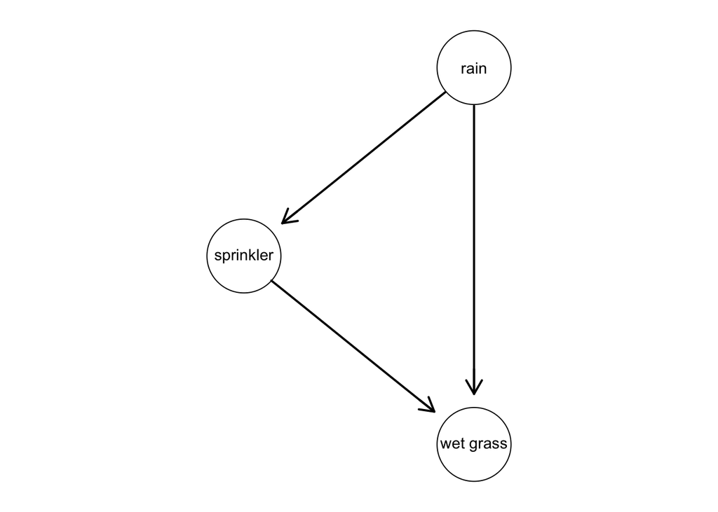

```r
# create random BN and label variables
set.seed(6)
myBayesNet <- randomBN(3)
myBayesNet@variables <- c("rain", "sprinkler", "wet grass")
plot(myBayesNet)
```

With inference we mean calculating the probability of a single variable, e.g. rain.

```r
# what's the probability of having rain?
# define observed variables and calculate marginal probability
myObserved <- list(observed.vars=c("rain"), observed.vals=c(2))
exactInference(myBayesNet,myObserved)
```

```
## [1] 0.6645466
```

With marginal probability we mean calculating the probability of multiple variables, e.g. rain and wet grass.

```r
# what's the probability of having rain and wet grass at the same time?
# define observed variables and calculate marginal probability
myObserved <- list(observed.vars=c("rain", "wet grass"), observed.vals=c(2,2))
exactInference(myBayesNet,myObserved)
```

```
## [1] 0.4193774
```

Next, let’s consider a more high-dimensional problem. Assume, we have measured 100 genes and would like to know what the probability of 4 particular genes is. We will use both exact and approximate inference to get the marginal probability distribution. For approximate inference, we use the efficient SGS algorithm (default) and the famous loopy belief propagation algorithm as a reference.

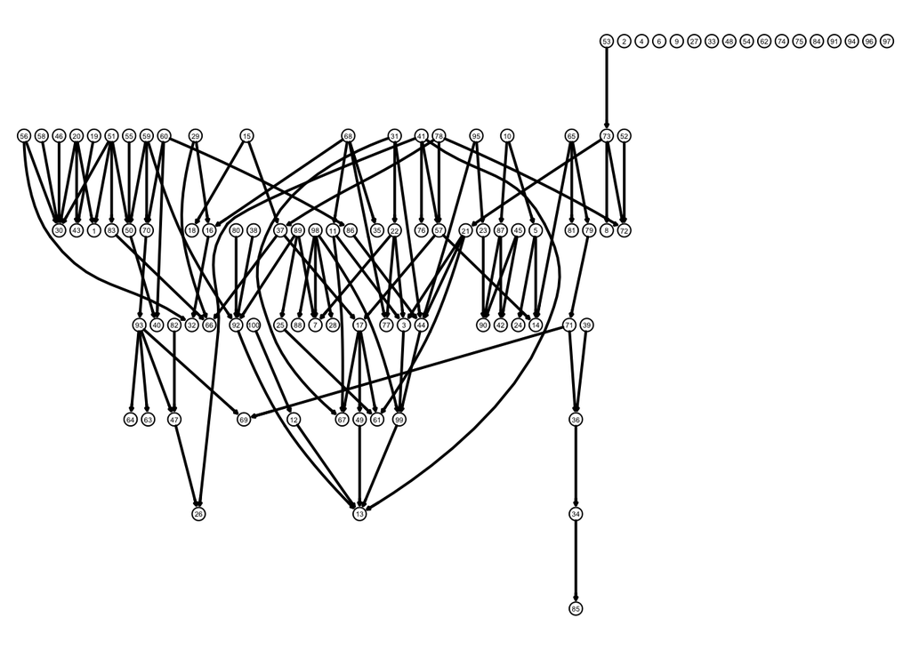

```r
# create random BN and label variables
set.seed(1)
myBayesNet <- randomBN(100)
plot(myBayesNet)
```

```r
# what's the probability of having rain and wet grass at the same time?
# define observed variables and calculate marginal probability
myObserved <- list(observed.vars=c(49,40,44,47), observed.vals=c(2,1,2,1))
exactInference(myBayesNet,myObserved)
```

```
## [1] 0.05815955
```

```r
approxInference(myBayesNet,myObserved)
```

```
## [1] 0.05759497
```

```r
approxInference(myBayesNet,myObserved, s_method = "LBP")
```

```
## [1] 0.05650207
```